```python
%matplotlib notebook
import numpy as np
import matplotlib.pyplot as plt
from scipy.constants import Avogadro
from mpl_toolkits.mplot3d import Axes3D
import sys
import timeit
```

##### Francis Mitchell | 10331083

# Project 3: Monte Carlo Techniques

# *Penetration of Neutrons Through Shielding*

## Introduction to neutron transport and Monte Carlo techniques

Neutron transport is the study of how neutrons diffuse through and interact with materials, such as the shielding on a nuclear reactor. This theory is the start point for reactor theory, but also has applications in other areas of physics, such as plasma physics $^{[1]}$. In this report, neutron transport through homogenous, and later simple heterogenous, shielding will be investigated using Monte Carlo techniques.

#### Monte Carlo method & simulation

The Monte Carlo method, invented by John von Neumann and Stanislaw Ulam during the Second World War, is a mathematical method used to estimate the possible outcomes of uncertain events $^{[2]}$. Monte Carlo simulations see wide use in industries that deal with risk and uncertainty. A business might, for instance, employ Monte Carlo techniques when forecasting sales and predicting stock prices. And of course Monte Carlo techniques are also used in scientific processes with a probabilistic nature.

The key operating principle of the Monte Carlo method is that for a given fixed input, the Monte Carlo simulation will predict a set of outcomes based on an estimated range of values. The possible outcomes are obtained by sampling probability distributions (e.g., normal distribution) with a pre-defined range for variables with intrinsic randomness, for example the distance a particle will move before being scattered. Many (thousands, maybe millions) of independent simulations are run providing data that can be analysed using statistical approaches.

#### Monte Carlo neutron transport

Monte Carlo neutron transport involves the independent simulation of many neutrons $^{[3]}$. The history of each neutron is recorded from a specific start point (other variables, for instance energy, could also be specified) and recorded until the neutron's 'death' - the particle is either absorbed by the shielding, reflected (backscattered), or transmitted through the shielding.

The history of the neutron is known as a random walk. At each step in the walk, the neutron moves a distance sampled from an exponential distribution that takes the total macroscopic cross-section of the material as a parameter. The direction the neutron takes is sampled from an isotropic unit sphere. At each step, there is a chance that the neutron will be absorbed by the shielding - this ends the history of that particular neutron. Otherwise, the neutron will continue its random walk until it is either transmitted (passes through the shielding), reflected (returns back out of the shielding interface), or absorbed at a later time.

1. https://www.sciencedirect.com/topics/engineering/neutron-transport
2. https://www.ibm.com/cloud/learn/monte-carlo-simulation
3. https://www.sciencedirect.com/book/9780128181904/nuclear-power-plant-design-and-analysis-codes

## Week 1

### Pseudo-random number generators

Since the processes described, such as sampling the step size of the neutron, are random processes, it is necessary for a good Monte Carlo simulation to utilise a random number generator capable of producing uniformly distributed random numbers. Truly random numbers are difficult to generate, since computers and algorithms are inherently deterministic $^{[1]}$. A pseudo-random number generators job is to efficiently generate a set of numbers that appear uniformly distributed over a given range of values.

In this section we will discuss the implementation of pseudo-random number generators, the issues that they can face, and the option that we will be using for this project.

#### Implementation of an LCG

A linear congruential generator is a method of generating pseudo-random numbers. We define a list of pseudo-random numbers $X$ defined by a recurrence relation,

$$ X_{n+1} = (aX_n + c) \ \textrm{mod} \ m. $$

The variables are bounded:

$$ 0 < m, \\ 0 < a < m, \\ 0 \leq c < m, \\ 0 \leq X_0 < m, $$

where $a$ is known as the multiplier, $c$ the increment, $X_0$ the seed value.

One important flaw of LCGs is their intrinsic periodicity. However, with careful choice of variables (so-called 'magic numbers'), this periodicity is very long and LCGs can generate numbers that appear uniformly distributed.

#### Built-in method

The method that we will be using to generate random numbers in this project is the `numpy.random.uniform()` function. This function takes low and high bounds, and a size parameter that specifies the number of values to sample. The function returns a uniformly distributed sample of random numbers within the specified interval $^{[2]}$.

#### Comparison of the two methods

We will now compare these two methods by generating an identical number of samples and displaying how well distributed each set of samples is through the use of histograms.

1. https://www.geeksforgeeks.org/pseudo-random-number-generator-prng/
2. https://numpy.org/doc/stable/reference/random/generated/numpy.random.uniform.html?highlight=uniform#numpy.random.uniform

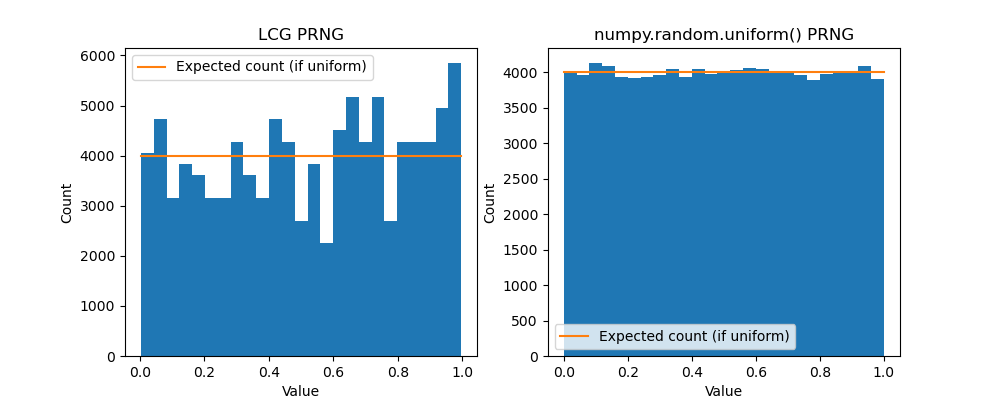

```python
def simple_lcg():
    a = 62 # Variables a, c, m, x chosen at random (by a me, a human, just typing random number keys)
    c = 726
    m = 9685

    x = 752 # seed

    while True:
        x = (a * x + c) % m

        yield x / m

lcg_sample_generator = simple_lcg()

fig = plt.figure(figsize=(10, 4))

num_samples = 100000
num_bins = 25

s = [next(lcg_sample_generator) for i in range(num_samples)] # List comprehension to yield samples
ax1 = fig.add_subplot(1, 2, 1)
count, bins, ignored = ax1.hist(s, num_bins)
ax1.plot(bins, np.ones_like(bins) * num_samples / num_bins, label='Expected count (if uniform)')
ax1.set_title('LCG PRNG')
ax1.set_xlabel('Value')
ax1.set_ylabel('Count')
ax1.legend()

upper_bound = 1 # 1 and 0 are actually the default values, but written explicitly here for demonstrative purposes
lower_bound = 0

s = np.random.uniform(upper_bound, lower_bound, size=num_samples)
ax2 = fig.add_subplot(1, 2, 2)
count, bins, ignored = ax2.hist(s, num_bins)
ax2.plot(bins, np.ones_like(bins) * num_samples / num_bins, label='Expected count (if uniform)')
ax2.set_title('numpy.random.uniform() PRNG')
ax2.set_xlabel('Value')
ax2.set_ylabel('Count')
ax2.legend()

fig.show()
```

Clearly we can see that the LCG that we have written has a strong bias towards generating values in some certain intervals, and an unbias to other intervals. This issue is not present with `numpy.random.uniform()`, hence our decision to use it in this project.

#### Spectral test

Plotting the points generated by our LCG reveals even more striking flaws in this approach.

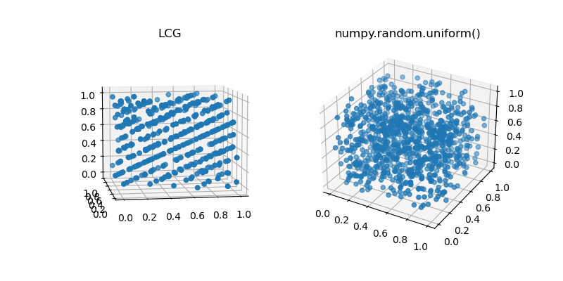

```python
N = 1000 # Number of points to sample
sample_points = np.array([next(lcg_sample_generator) for i in range(3 * N)]) # Multiply by 3 for x, y, z coords
sample_points = sample_points.reshape((3, N)) # Reshape into series array of vectors

fig = plt.figure(figsize=(8, 4))

ax1 = fig.add_subplot(1, 2, 1, projection='3d')
ax1.scatter(sample_points[0], sample_points[1], sample_points[2])
ax1.set_title('LCG')

N = 1000 # Number of points to sample
sample_points = np.random.uniform(0, 1, size=(3 * N)) # Multiply by 3 for x, y, z coords
sample_points = sample_points.reshape((3, N)) # Reshape into series array of vectors

ax2 = fig.add_subplot(1, 2, 2, projection='3d')
ax2.scatter(sample_points[0], sample_points[1], sample_points[2])
ax2.set_title('numpy.random.uniform()')
fig.show()
```

Rotating the plotted points generated by the LCG (left) reveals the presence of hyperplanes. This is an example of Marsaglia's theorem - LCGs have a crucial flaw in that lead to the creation of parallel hyperplanes containing sets of generated numbers. This spectral problem is not present when using `numpy.random.uniform()` (right) as the points do not lie on hyperplanes.

Clearly, since Monte Carlo simulations rely on having uniformly distributed variables in order to simulate as many possible outcomes as possible, using our LCG would not be appropriate for this, or any Monte Carlo simulation. For this reason, and since we have verified that it generates numbers that appear uniformly distributed over a given range, we will be using `numpy.random.uniform()`.

### Non-uniform distributions

#### Gaussian variates using the central limit theorem

If you have a sufficiently large random sample, the central limit theorem states that the distribution will be approximately normally distributed. For instance, if you flip a coin a hundred times and record the number of heads and then repeat this experiment many times (1000 times, for example), the number of heads recorded per experiment should be normally distributed around a mean of 50.

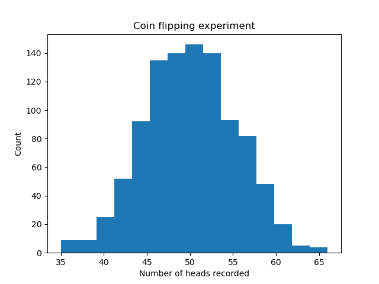

```python
flips = 100
experiments = 1000
results = []

def coin_flip_exp(flips):
    heads = 0

    for _ in range(flips):
        if np.random.uniform() >= 0.5: heads += 1

    return heads

for _ in range(experiments):
    results.append(coin_flip_exp(flips))

plt.figure()
plt.hist(results, 15)
plt.title('Coin flipping experiment')
plt.xlabel('Number of heads recorded')
plt.ylabel('Count')
plt.show()
```

The central limit theorem holds true provided that the sample size is sufficiently large enough, usually at least 30 samples $^{[1]}$.

The following code generates a random distribution whose PDF is that of a Gaussian distribution, centred around 0.

1. https://sphweb.bumc.bu.edu/otlt/MPH-Modules/BS/BS704_Probability/BS704_Probability12.html

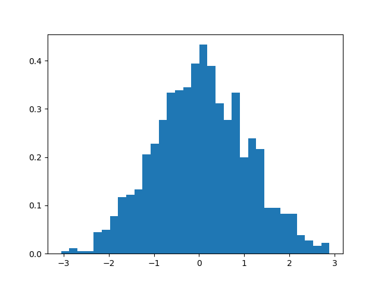

```python
n = 12
gauss_s = []

for i in range(1000):
    s = np.random.uniform(0, 1, n)
    g = (np.sum(s) - n / 2) / np.sqrt(n / 12)
    gauss_s.append(g)

plt.figure()
count, bins, ignored = plt.hist(gauss_s, 33, density=True)
plt.show()
```

#### The Box-Muller transformation

Handy way of generating Gaussians using 2 uniformly distributed random variables.

The Box-Muller transform takes two uniformly distributed samples between 0 and 1 and maps them to two normally distributed samples.

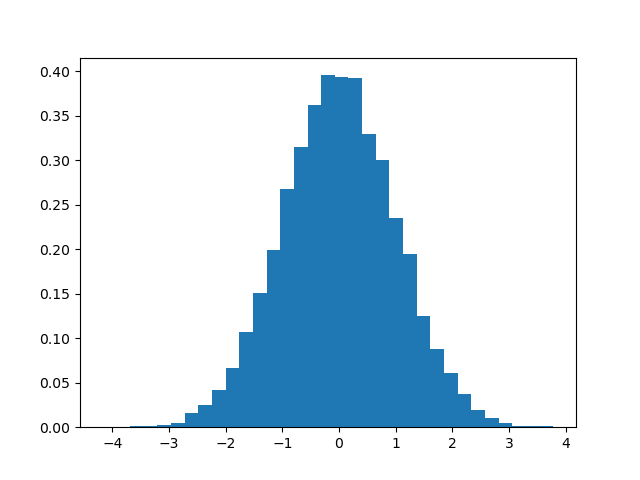

```python
samples = []

for i in range(10000):
    U_1, U_2 = np.random.uniform(0, 1, size=2)
    Z_0 = np.sqrt(-2 * np.log(U_1)) * np.cos(2 * np.pi * U_2)
    Z_1 = np.sqrt(-2 * np.log(U_1)) * np.sin(2 * np.pi * U_2)

    samples.append(Z_0)
    samples.append(Z_1)

plt.figure()
count, bins, ignored = plt.hist(samples, 33, density=True)
plt.show()
```

#### Inverse distribution sampling/cumulative distribution sampling

This method generates a non-uniformly distributed sample by doing the following $^{[1]}$:

1. Generate a random uniform number between 0 and 1
2. Find the inverse function of the desired PDF distribution
3. Input the random uniform number into the inverse function. The inverse function maps the input value to the desired PDF distribution.

1. http://www.columbia.edu/~ks20/4404-Sigman/4404-Notes-ITM.pdf

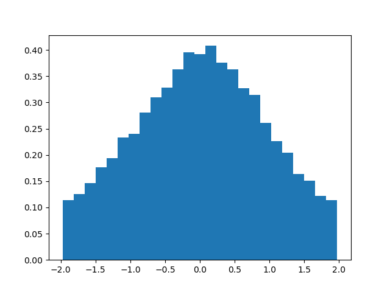

```python
def inverse_error_function(x):

    return 0.5 * np.sqrt(np.pi) * (x + x**3 * np.pi / 12 + x**5 * 7 * np.pi**2 / 480 + x**7 * 127 * np.pi**3 / 40320 + x**9 * 4369 * np.pi**4 / 5806080)

def inverse_cumulative_distribution_function(x):

    return np.sqrt(2) * inverse_error_function(2 * x - 1)

s = inverse_cumulative_distribution_function(np.random.uniform(0, 1, 10000))

plt.figure()
count, bins, ignored = plt.hist(s, 25, density=True)
plt.show()
```

### Von Neumann rejection method

Another method of generating a non-uniformly distributed random sample.

In this case, a 2D array of uniformly distributed random coordinates has been generated. Then, for the desired PDF, each point is iteratively evaluated: if the y-coordinate of any point is less than the value of PDF evaluated at the x-coordinate of that same point, it is accepted - otherwise it is rejected. The x-coordinates of the accepted points then make up the desired sample.

```python
N = 1000 # Number of points to sample
sample_points = np.random.uniform(0, 2, size=(2 * N)) # Multiply by 3 for x, y, z coords
sample_points_x = np.random.uniform(0, 4, size=N)
sample_points_y = np.random.uniform(0, 1.1, size=N)
sample_points = np.vstack((sample_points_x, sample_points_y))

accepted = []
rejected = []

def func(x):

    return np.e**-x

for point in sample_points.T:
    if point[1] < func(point[0]):
        accepted.append(point)
    else:
        rejected.append(point)



fig = plt.figure()
ax1 = plt.add_subplot(1, 2, 1)
ax1.scatter(np.array(accepted).T[0], np.array(accepted).T[1])
ax1.scatter(np.array(rejected).T[0], np.array(rejected).T[1])
ax2 = plt.add_subplot(1, 2, 2)
ax2.hist(np.array(accepted).T[0], 33)
fig.show()
```

[output not shown]

### Determining the characteristic attenuation length in water using an exponentially distributed random sample (no scattering, absorption only)

#### Characteristic attenuation length

The attenuation length, $\lambda$, is the distance that a particle travels through a material before the probability that it has been absorbed drops to 1/$e$ $^{[1]}$. The Beer-Lambert law states that the probability that a particle makes it distance $x$ into a material is given by,

$$ P(x) = e^{-x/\lambda}, $$

therefore, in the many particle limit, the distance that the neutrons make it into the shielding will be exponentially distributed with a rate given by,

$$ -\frac{1}{\lambda}, $$

hence taking the log of the curve of the distribution described by the Beer-Lambert law will gives a straight line with a gradient equal to this rate, from which it is trivial to find the characterstic attenuation length, $\lambda$.

#### Finding the charactersitic attenuation length by sampling an exponentially distributed sample

The exponentially distributed random sample is generated using the inverse sampling method. The probability that a neutron is attenuated after travelling a distance $x$ is again given by the Beer-Lambert law,

$$ f(x) = e^{-x/\lambda}, $$

where $\lambda$ is the mean free path. To generate the exponentially distributed random sample we first take the inverse,

$$ f(f^{-1}(u)) = u, \\ e^{-f^{-1}(u) / \lambda} = u, \\ f^{-1}(u) = - \lambda \log(u), $$

where $u$ is a uniformly distributed random variable. Given an input of a uniformly distributed random value, the inverse function will now output an exponentially distributed random sample. Let's now implement this and verfiy that the generated sample is actually exponentially distributed.

#### Microscopic and macroscopic cross-sections

To benchmark our method, we first need to obtain a theoretical expected value.

The microscopic cross-section of a nucleus, $\sigma$, (units cm$^2$ or barn - a unit equal to 1$\times$10$^{-24}$ cm$^2$ that is commonly used in nuclear physics) is the target area presented by a nucleus to an incident neutron beam $^{[2]}$. The larger the area, the greater the probability of interaction. Scattering and absorption have different microscopic cross-sections, with scattering usually being greater than absorption, since scattering is a much more likely process to happen than absorption for any given single event. In this case we are only interested in absorption, so we will ignore the microscopic cross-section for scattering for now.

The macroscopic cross-section, $\Sigma$, (units cm$^-1$) is the effective target area of all the nuclei contained within a volume. It is related to the microscopic cross-section by,

$$ \Sigma = n \sigma, $$

where $n$ is the density of absorbing particles given in cm$^{-3}$.

The total macroscopic cross-section of a material, $\Sigma_T$, can be calculated by simply summing each of the individual macroscopic cross-sections. The total mean free path, $\lambda_T$ can then be calculated by taking the reciprocal of the total macroscopic cross-section,

$$ \lambda_T = \frac{1}{\Sigma_T}, $$

in this case, since we are considering absorption only, the total mean free path is equal to the characteristic attenuation length of water.

1. http://gisaxs.com/index.php/Absorption_length
2. https://www.nuclear-power.net/nuclear-power/reactor-physics/nuclear-engineering-fundamentals/neutron-nuclear-reactions/microscopic-cross-section/

```python
# This function will be used later in our Monte Carlo model
def exponential_distribution(size, mean_free_path):
    s = - mean_free_path * np.log(np.random.uniform(0, 1, size))

    return s
```

```
Theoretical mean free path: 44.972
```

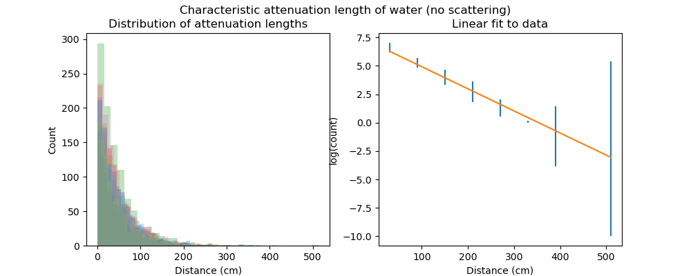

```
Characteristic attenuation length (water) = 51.392 +- 0.001 cm
```

```python
# Find theoretical mean free path
n = 1.00 * Avogadro / 18.0153
mean_free_path = 1 / (n * 0.6652 * 1e-24)

print('Theoretical mean free path: {:.3f}'.format(mean_free_path))

fig = plt.figure(figsize=(10, 4))
fig.suptitle('Characteristic attenuation length of water (no scattering)')


ax1 = fig.add_subplot(1, 2, 1)
# Repeat sampling of exponential distribution with rate given by mean_free_path
num_repeats = 10
num_bins = 10
num_neutrons = 1000

data = np.zeros((num_repeats, num_bins))

for i in range(num_repeats):
    s = exponential_distribution(num_neutrons, mean_free_path)
    ax1.hist(s, 33, alpha=0.3)

    count, bins = np.histogram(s, num_bins, range=(0,600))

    data[i] = count

std = np.std(data, axis=0)
mean = np.mean(data, axis=0)
bin_centre = (bins[1:] + bins[:-1])/2

# Discard entries with value of zero - no log solution
indices_to_keep = np.nonzero(mean)
bin_centre = bin_centre[indices_to_keep]
mean = mean[indices_to_keep]
std = std[indices_to_keep]

# Find error and weightings
error = mean / std
frac_error = error / mean
log_mean = np.log(mean)
error_log_mean = frac_error * log_mean
weightings = 1 / error

# polyfit
coef, covr = np.polyfit(bin_centre, log_mean, 1, cov=True)
fit = np.polyval(coef, bin_centre)

# Plot results
ax1.set_title('Distribution of attenuation lengths')
ax1.set_xlabel('Distance (cm)')
ax1.set_ylabel('Count')
ax2 = fig.add_subplot(1, 2, 2)
ax2.errorbar(bin_centre, log_mean, yerr=error_log_mean, linestyle='none')
ax2.plot(bin_centre, fit)
ax2.set_title('Linear fit to data')
ax2.set_xlabel('Distance (cm)')
ax2.set_ylabel('log(count)')

fig.show()

exp_mean_free_path = - 1 / coef[0]
error_mean_free_path = np.sqrt(np.diag(covr)[0])
print('Characteristic attenuation length (water) = {:.3f} +- {:.3f} cm'.format(exp_mean_free_path, error_mean_free_path))
```

The figure on the left also illustrates the effect of doing multiple simulations - although some simulation runs may not fully represent the whole distribution (since the sampled values are random), the effect of doing multiple simulations 'fills in' those gaps. For the same reason, the attenuation length calculated is not the same as the theoretical value - the randomness of this process means that biases appear, which need to be mitigated by taking much more data.

## Week 2

### Generating points on a sphere (isotropic unit vectors)

Every step taken by a scattered neutron should be in a random direction. A unit vector will be generated to determine this direction, which will then be multiplied by the step size sampled from the exponential distribution.

$$ \theta = cos^{-1}(1 - 2u_i), $$

where $u_i$ is a uniformly distributed random value.

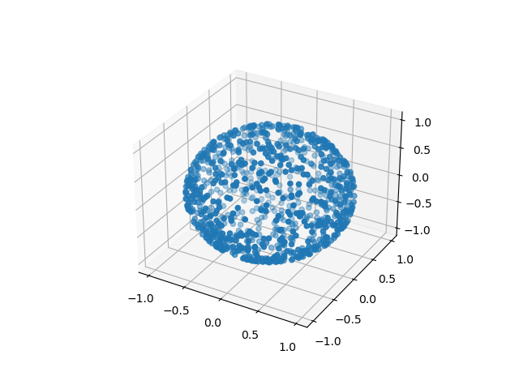

```python
def isotropic_unit_surface_distribution(size):
    R = 1
    s = np.zeros((3, size))

    theta = np.arccos(1 - 2 * np.random.uniform(0, 1, size))
    phi = np.random.uniform(0, 2 * np.pi, size)

    s[0] = R * np.sin(theta) * np.cos(phi)
    s[1] = R * np.sin(theta) * np.sin(phi)
    s[2] = R * np.cos(theta)

    return s

N = 1000

sample_vector = isotropic_unit_surface_distribution(N)

fig = plt.figure()
ax = fig.add_subplot(projection='3d')
ax.scatter(sample_vector[0], sample_vector[1], sample_vector[2])
fig.show()
```

### Generating isotropic steps

We will now write generate a 'random walk' of a particle. A random walk is the name given for a process in which an object moves away from its start position, taking random length steps in random directions. The process can be applied in any number of dimensions $^{[1]}$.

#### Pseudocode

`START LOOP`

`step direction = unit vector sampled from isotropic distribution`

`step length = length scalar sampled from exponential distribution`

`step = step direction * step length`

`move step`

`END LOOP`

For now, we will implement this using a fixed amount of steps; however, later we will use conditional statements to break the loop depending on events that may arise.

1. https://www.mit.edu/~kardar/teaching/projects/chemotaxis(AndreaSchmidt)/random.htm

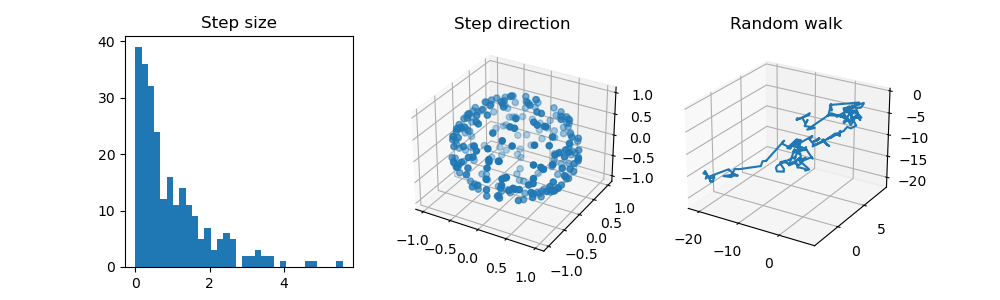

```python
N = 250 # number of steps to compute

history = np.zeros((N, 3)) # history of steps

step_direction = isotropic_unit_surface_distribution(N)

step_length = exponential_distribution(N, 1)

step_array = step_direction * step_length

for i in range(N - 1):
    history[i + 1] = history[i] + step_array.T[i]

fig = plt.figure(figsize=(10, 3))
ax1 = fig.add_subplot(1, 3, 1)
ax1.hist(step_length, 33)
ax1.set_title('Step size')
ax2 = fig.add_subplot(1, 3, 2, projection='3d')
ax2.scatter(step_direction[0], step_direction[1], step_direction[2])
ax2.set_title('Step direction')
ax3 = fig.add_subplot(1, 3, 3, projection='3d')
ax3.plot(history.T[0], history.T[1], history.T[2])
ax3.set_title('Random walk')
fig.show()
```

Each of the steps represented on the left-most figure and each of the directions in the middle figure are represented in the figure on the right showing the random walk. At low values of N you can see how the random walk is pieced together.

## Week 3-5

### Neutron history calculation

Now let us add the exit conditions, i.e. when the neutron is reflected or transmitted. Also add a random number generator to decide whether the neutron will be absorbed or scattered.

#### Absorption condition

After the neutron travels a distance sampled from the exponential distribution, one of two things will happen:

1. The neutron is absorbed
2. The neutron is scattered

Whether the neutron is absorbed or scattered depends on the macroscopic cross-section of the neutron, with the probability of being absorbed given by:

$$ P_a = \frac{\Sigma_a}{\Sigma_a + \Sigma_s}. $$

This is modelled as a random process, therefore we will need a uniform random number, $u$. The two events are now decided as follows:

1. The neutron is absorbed if $u < P_a$
2. The neutron is scattered if $u > P_a$

If the neutron is absorbed, its history ends there and a counter tracking the number of absorptions is incremented. Otherwise the neutron is scattered and the process is repeated.

#### Reflection and transmission conditions

What happens if the neutron leaves the shielding? After every step the neutron takes, a check must be made to ensure that the neutron is still within the shielding, as clearly the neutron cannot be absorbed or scattered by the sheidling if it is not within it. If the neutron has exited the side of the shielding that it entered, it has been *reflected*. If the neutron passes through the other side of the shielding, it has been *transmitted*. If either of these conditions have been met at the time of the check, the particle is killed and the respective counter is incremented.

```python
class neutron_penetration_simulation:

    def __init__(self, density, molar_mass, sigma_a, sigma_s, name):
        self.density = density
        self.molar_mass = molar_mass
        self.sigma_a = sigma_a
        self.sigma_s = sigma_s

        self.name = str(name)

        self.n_absorbers = density * Avogadro / molar_mass # cm^-3

        # Determine the macroscopic absorption and scattering cross sections
        self.Sigma_a = self.n_absorbers * sigma_a
        self.Sigma_s = self.n_absorbers * sigma_s
        self.Sigma_T = (self.Sigma_a + self.Sigma_s) * 1e-24 # barn
        # Determine the total mean free path
        self.total_mean_free_path = 1 / self.Sigma_T

        self.P_a = self.Sigma_a / (self.Sigma_a + self.Sigma_s)
        self.P_s = self.Sigma_s / (self.Sigma_a + self.Sigma_s)

        # Counters
        self.neutrons_simulated = 0

        self.transmitted = 0
        self.reflected = 0
        self.absorbed = 0

        self.thickness = 0

        self.latest_history = None

    # Function to generate 3D random step vector, takes mean free path as input
    def generate_step(self, mean_free_path):
        step_direction = isotropic_unit_surface_distribution(1)

        step_length = exponential_distribution(1, mean_free_path)

        return (step_direction * step_length).T

    def simulate_penetration(self, slab_thickness):
        self.thickness = slab_thickness
        # Send one neutron through the shielding

        # Particle starts at (0, 0, 0), i.e. the face of the slab
        history = np.zeros(3)
        history = history.reshape((1, 3))

        i = 0
        while True:
            if i==0:
                # First step move in x direction only - step length still sampled from exp. dist.
                history = np.append(history, np.array([exponential_distribution(1, self.total_mean_free_path) * np.array([1, 0, 0])]), axis=0)

                i = 1

                continue

            # Move particle - this should always be the first process
            history = np.append(history, history[i] + self.generate_step(self.total_mean_free_path), axis=0)

            # Has particle been transmitted?
            if history[i][0] > slab_thickness:
                self.transmitted += 1

                break

            # Has particle been reflected?
            if history[i][0] < 0:
                self.reflected += 1

                break

            # Has particle been absorbed?
            if np.random.uniform() < self.P_a:
                # Particle absorbed
                self.absorbed += 1

                break

            i += 1

        # Save latest history - used for visualising random walk
        self.latest_history = history

        # Calculate how far the neutron has travelled
        #diff = history[1:] - history[:-1]
        #dist = np.sum(np.sqrt(np.sum(diff * diff, axis=1)))

        #return dist

    def simulate_penetration_batch(self, slab_thickness, neutrons, visualise):
        # Send a batch of neutrons through the shielding
        # Histories used to visualise a selection of random walks
        sample_histories = []

        # Note: you can keep calling this command and it will simulate more neutrons without
        # resetting the totals unless the slab_thickness changes
        if slab_thickness != self.thickness:
            self.reset_counts()

        for i in range(neutrons):
            self.simulate_penetration(slab_thickness)
            self.neutrons_simulated += 1

            if i % (neutrons / 100) == 0:
                sample_histories.append(self.latest_history)

        return sample_histories


    def simulate_different_thicknesses(self, thicknesses, iterations, neutrons_per_iterations, visualise=False):
        start = timeit.default_timer()
        # Send multiple batches of neutrons through multiple thicknesses of shielding
        # First reset counters
        self.reset_counts()

        if visualise:
            fig = plt.figure()
            ax = fig.add_subplot(projection='3d')
            max_val = 0

        data = np.zeros((len(thicknesses), iterations, 3))

        for i, thickness in enumerate(thicknesses):

            N_a = []
            N_t = []
            N_r = []

            for j in range(iterations):
                sys.stdout.write("Simulating thickness {:.3f} cm ({}/{}) | Iteration {}/{}                           \r".format(thickness, i+1, len(thicknesses), j+1, iterations))
                sys.stdout.flush()
                histories_to_plot = self.simulate_penetration_batch(thickness, neutrons_per_iterations, visualise)
                N_a.append(self.absorbed)
                N_t.append(self.transmitted)
                N_r.append(self.reflected)
                self.reset_counts()

            data[i] = np.array([N_a, N_r, N_t]).T

        if visualise:
            for hist in histories_to_plot:
                ax.plot(hist.T[0], hist.T[1], hist.T[2])

                # Save maximum y or z value for use in dynamically adjusting the plane
                max_val = np.max((max_val, np.max(hist.T[1:])))

            # Add planes corresponding to start and end of shielding slab
            plane_limit = max(1, abs(round(max_val)))
            yy, zz = np.meshgrid(np.arange(-plane_limit, plane_limit + 1), np.arange(-plane_limit, plane_limit + 1))
            surf = ax.plot_surface(0 * np.ones((len(yy), len(zz))), yy, zz, alpha=0.2)
            surf = ax.plot_surface((self.thickness) * np.ones((len(yy), len(zz))), yy, zz, alpha=0.2)

            ax.set_xlabel('Shielding thickness (cm)')

        # For the case of only one thickness being simulated, print out the data (don't graph)
        if len(thicknesses) == 1:
            self.neutrons_simulated = iterations * neutrons_per_iterations
            self.absorbed = np.sum(data, axis=1)[0][0]
            self.reflected = np.sum(data, axis=1)[0][1]
            self.transmitted = np.sum(data, axis=1)[0][2]
            self.error_analysis_and_plotting(data, None)
        else:
            self.neutrons_simulated = iterations * neutrons_per_iterations
            self.error_analysis_and_plotting(data, thicknesses)
```

```python
        stop = timeit.default_timer()
        print('Runtime: {:.3f} seconds'.format(stop - start))

        return data

    def reset_counts(self):
        # Reset counters
        self.absorbed = 0
        self.transmitted = 0
        self.reflected = 0
        self.neutrons_simulated = 0

    def print_simulation_info(self):
        # Old function - but could still have some utility
        print('----------------------------------------')
        print('Transmission through {}'.format(self.name))
        print('----------------------------------------')
        print('Thickness: {} cm'.format(self.thickness))
        print('Total neutrons: {}'.format(self.neutrons_simulated))
        print('Neutrons reflected: {0} ({1:.2f}%)'.format(self.reflected, 100 * self.reflected / self.neutrons_simulated))
        print('Neutrons absorbed: {0} ({1:.2f}%)'.format(self.absorbed, 100 * self.absorbed / self.neutrons_simulated))
        print('Neutrons transmitted: {0} ({1:.2f}%)'.format(self.transmitted, 100 * self.transmitted / self.neutrons_simulated))

    def error_analysis_and_plotting(self, data, thicknesses):
            mean = np.mean(data, axis=1)
            std = np.std(data, axis=1)
            #SE = np.std(data, axis=1)[0] / np.sqrt(data.shape[1])

            percentages = 100 * np.array([self.absorbed / self.neutrons_simulated,
                                            self.reflected / self.neutrons_simulated,
                                            self.transmitted / self.neutrons_simulated])

            error = mean / std
            frac_error = error / mean

            gaussian_error = np.sqrt(mean)

            #compare errors print('\n\n\n\n\n{}\n{}'.format(error, gaussian_error))

            # Case where only one thickness was simulated (no graphing)
            if data.shape[0] == 1:
                mean = mean[0]
                error = error[0]
                percent_error = (frac_error * percentages)[0]



                print('========================================================')
                print('Transmission through {}'.format(self.name))
                print('--------------------------------------------------------')
                print('Thickness: {} cm'.format(self.thickness))
                print('Neutrons per run: {}'.format(int(self.neutrons_simulated / data.shape[1])))
                print('Total neutrons: {}'.format(self.neutrons_simulated))
                print('--------------------------------------------------------')
                print('Mean reflected: {} +- {:.1f}'.format(mean[1], error[1]))
                print('Mean absorbed: {} +- {:.1f}'.format(mean[0], error[0]))
                print('Mean transmitted: {} +- {:.1f}'.format(mean[2], error[2]))
                print('--------------------------------------------------------')
                print('Mean reflected %: {:.1f} +- {:.1f}%'.format(percentages[1], percent_error[1]))
                print('Mean absorbed %: {:.1f} +- {:.1f}%'.format(percentages[0], percent_error[0]))
                print('Mean transmitted %: {:.1f} +- {:.1f}%\n'.format(percentages[2], percent_error[2]))

            else:

                fig = plt.figure(figsize=(10, 4))
                fig.suptitle('Neutron scattering processes ({} neutrons per thickness)'.format(self.neutrons_simulated))
                ax1 = fig.add_subplot(1, 2, 1)
                ax1.errorbar(thicknesses, mean.T[0], yerr=error.T[0], label='Absorbed', linestyle='none')
                ax1.errorbar(thicknesses, mean.T[1], yerr=error.T[1], label='Reflected', linestyle='none')
                ax1.errorbar(thicknesses, mean.T[2], yerr=error.T[2], label='Transmitted', linestyle='none')
                ax1.legend()


                transmission_errors = error.T[2]

                # Remove vals where no neutrons are transmitted
                transmission_vals = mean.T[2][np.nonzero(mean.T[2])]
                transmission_stds = std.T[2][np.nonzero(mean.T[2])]
                transmission_errors = transmission_errors[np.nonzero(mean.T[2])]
                thickness_vals = thicknesses[np.nonzero(mean.T[2])]

                # Remove vals where the standard deviation is zero - usually when all neutrons are transmitted
                transmission_vals = transmission_vals[np.nonzero(transmission_stds)]
                thickness_vals = thickness_vals[np.nonzero(transmission_stds)]
                transmission_errors = transmission_errors[np.nonzero(transmission_stds)]
                transmission_stds = transmission_stds[np.nonzero(transmission_stds)]

                # Percent errors for taking logs
                frac_transmission_error = transmission_errors / transmission_vals
                log_transmission_vals = np.log(transmission_vals)
                log_transmission_errors = frac_transmission_error * log_transmission_vals

                # Used for weighted polyfit
                transmission_weights = transmission_vals / transmission_stds

                # Do a weighted polyfit
                #coef, covr = np.polyfit(thickness_vals, log_transmission_vals, 1, w=transmission_weights, cov=True)

                # Unweighted polyfit
                coef, covr = np.polyfit(thickness_vals, np.log(transmission_vals), 1, cov=True)
                var = np.diag(covr)
                error_coef_0 = np.sqrt(var[0])
                frac_error_coef_0 = error_coef_0 / coef[0]

                fit = np.polyval(coef, thickness_vals)

                ax1 = fig.add_subplot(1, 2, 2)
                ax1.errorbar(thickness_vals, log_transmission_vals, log_transmission_errors, linestyle='none')
                ax1.plot(thickness_vals, fit)
                ax1.set_xlabel('Shielding thickness (cm)')
                ax1.set_ylabel('log(transmissed)')
                fig.show()

                # Mean free path
                mean_free_path = - 1 / coef[0]
                error_mean_free_path = -frac_error_coef_0 * mean_free_path

                print('Characteristic attenuation length ({}) = {:.3f} +- {:.3f} cm'.format(self.name, mean_free_path, error_mean_free_path))
```

### Test cases

To benchmark our Monte Carlo simulation, we will now run test cases where we will simulate 10 iterations of sending 1000 neutrons through 10 cm of shielding. We will test each of the three materials specified: water, lead and graphite.

#### 10 cm of water

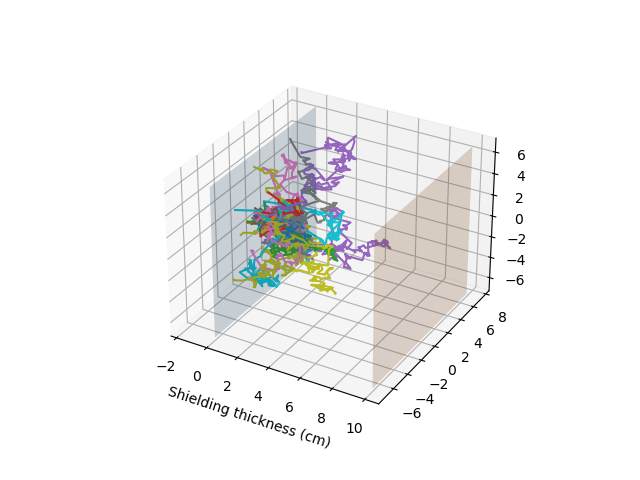

```
========================================================
Transmission through water
--------------------------------------------------------
Thickness: 10 cm
Neutrons per run: 1000
Total neutrons: 10000
--------------------------------------------------------
Mean reflected: 797.6 +- 65.8
Mean absorbed: 198.9 +- 16.8
Mean transmitted: 3.5 +- 1.7
--------------------------------------------------------
Mean reflected %: 79.8 +- 6.6%
Mean absorbed %: 19.9 +- 1.7%
Mean transmitted %: 0.4 +- 0.2%

Runtime: 12.744 seconds
```

```python
### WATER VALS ###
density = 1.00 # g/cm^3
molar_mass = 18.0153 # g mol^-1 from NIST
sigma_a = 0.6652 # barn
sigma_s = 103.0 # barn

water_shielding = neutron_penetration_simulation(density, molar_mass, sigma_a, sigma_s, 'water')

data = water_shielding.simulate_different_thicknesses([10], 10, 1000, True)
```

#### 10 cm of lead

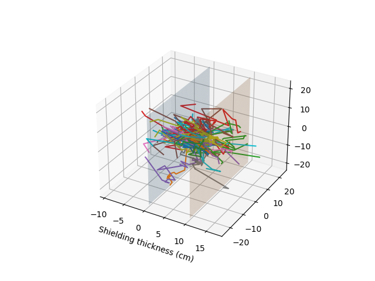

```
========================================================
Transmission through lead
--------------------------------------------------------
Thickness: 10 cm
Neutrons per run: 1000
Total neutrons: 10000
--------------------------------------------------------
Mean reflected: 609.7 +- 54.5
Mean absorbed: 107.1 +- 21.5
Mean transmitted: 283.2 +- 25.5
--------------------------------------------------------
Mean reflected %: 61.0 +- 5.4%
Mean absorbed %: 10.7 +- 2.1%
Mean transmitted %: 28.3 +- 2.5%

Runtime: 4.100 seconds
```

```python
### LEAD VALS ###
density = 11.35 # g/cm^3
molar_mass = 207.2 # g mol^-1 from NIST
sigma_a = 0.158 # barn
sigma_s = 11.221 # barn

lead_shielding = neutron_penetration_simulation(density, molar_mass, sigma_a, sigma_s, 'lead')

data = lead_shielding.simulate_different_thicknesses([10], 10, 1000, True)
```

#### 10 cm of graphite

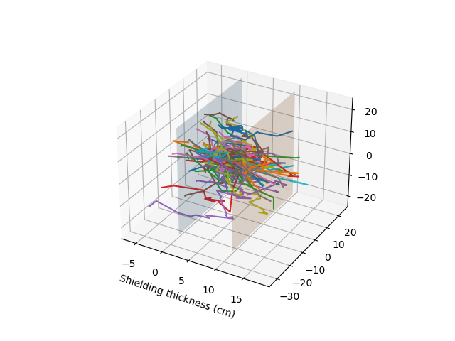

```
========================================================
Transmission through graphite
--------------------------------------------------------
Thickness: 10 cm
Neutrons per run: 1000
Total neutrons: 10000
--------------------------------------------------------
Mean reflected: 685.0 +- 76.4
Mean absorbed: 8.8 +- 2.8
Mean transmitted: 306.2 +- 32.8
--------------------------------------------------------
Mean reflected %: 68.5 +- 7.6%
Mean absorbed %: 0.9 +- 0.3%
Mean transmitted %: 30.6 +- 3.3%

Runtime: 4.087 seconds
```

```python
### GRAPHITE VALS ###
density = 1.67 # g/cm^3
molar_mass = 12.011 # g mol^-1 from NIST
sigma_a = 0.0045 # barn
sigma_s = 4.74 # barn

graphite_shielding = neutron_penetration_simulation(density, molar_mass, sigma_a, sigma_s, 'graphite')

data = graphite_shielding.simulate_different_thicknesses([10], 10, 1000, True)
```

#### Comment on the benchmarks

From the initial tests of our Monte Carlo model, we can see that the uncertainties are high for the number of neutrons used. This is because there is likely a high variance between each run of the number of neutrons undergoing each process. To decrease these variance, more simulation runs must be completed.

We can also see that 10 cm of water is the best shielding as the fewest number of neutrons were transmitted within a comfortable margin of error.

### How does the number of simulated neutrons affect the error?

Before varying the thickness of the shielding to work out the attenuation length, we first want to know the optimal number of neutrons to simulate. Too few neutrons and the uncertainties will be high; too many and the computational time will be too great. We will now test five different amounts of neutrons of different orders of magnitude to determine the optimal choice.

```python
# COMMENTED OUT SINCE THE FINAL TEST CASE (10 ITERATIONS OF 1,000,000 NEUTRONS) TAKES AN HOUR TO RUN
for n in [100, 1000, 10000, 100000]:
    graphite_shielding.simulate_different_thicknesses([10], 10, n)
```

```
========================================================
Transmission through graphite
--------------------------------------------------------
Thickness: 10 cm
Neutrons per run: 100
Total neutrons: 1000
--------------------------------------------------------
Mean reflected: 70.5 +- 13.8
Mean absorbed: 0.7 +- 0.9
Mean transmitted: 28.8 +- 6.1
--------------------------------------------------------
Mean reflected %: 70.5 +- 13.8%
Mean absorbed %: 0.7 +- 0.9%
Mean transmitted %: 28.8 +- 6.1%

Runtime: 0.460 seconds
========================================================
Transmission through graphite
--------------------------------------------------------
Thickness: 10 cm
Neutrons per run: 1000
Total neutrons: 10000
--------------------------------------------------------
Mean reflected: 676.1 +- 53.4
Mean absorbed: 7.4 +- 3.2
Mean transmitted: 316.5 +- 24.9
--------------------------------------------------------
Mean reflected %: 67.6 +- 5.3%
Mean absorbed %: 0.7 +- 0.3%
Mean transmitted %: 31.6 +- 2.5%

Runtime: 4.096 seconds
========================================================
Transmission through graphite
--------------------------------------------------------
Thickness: 10 cm
Neutrons per run: 10000
Total neutrons: 100000
--------------------------------------------------------
Mean reflected: 6836.6 +- 314.5
```

[output cut: 9 more lines]

```
Transmission through graphite
--------------------------------------------------------
Thickness: 10 cm
Neutrons per run: 100000
Total neutrons: 1000000
--------------------------------------------------------
Mean reflected: 68537.3 +- 669.6
Mean absorbed: 814.1 +- 35.5
Mean transmitted: 30648.6 +- 270.5
--------------------------------------------------------
Mean reflected %: 68.5 +- 0.7%
Mean absorbed %: 0.8 +- 0.0%
Mean transmitted %: 30.6 +- 0.3%

Runtime: 365.303 seconds
```

[figure not shown]

```python
neutrons = [100, 1000, 10000, 100000, 1000000]
reflected = [18.8, 9.1, 2.7, 0.7, 0.2]
absorbed = [150.8, 58.1, 10.9, 3.4, 1.1]
transmitted = [18.1, 9.3, 2.4, 0.7, 0.2]

plt.figure()
plt.scatter(np.log10(neutrons), reflected, label='Reflected', marker='^')
plt.scatter(np.log10(neutrons), absorbed, label='Absorbed', marker='o')
plt.scatter(np.log10(neutrons), transmitted, label='Transmitted', marker='x')
plt.legend()
plt.title('Percentage error against neutrons simulated')
plt.xlabel('log(number neutrons simulated)')
plt.ylabel('Percentage error')
plt.show()
```

From the graph above, we can see that after simulating around 10,000 neutrons, the uncertainty on the transmission values (that we will be using to find the attenuation lengths) do not improve by much, therefore to save on computation time, we will only simulate on the order of a few thousand neutrons per iteration.

### Determining the characteristic attenuation length by varying shielding thickness

#### Water

On first pass, we can see that the change in the number of neutrons being absorbed, reflected or scattered plateaus after about 11~12 cm of shielding, so we will only go up to that amount to save computing time.

```
Simulating thickness 11.100 cm (12/12) | Iteration 10/10
```

[figure not shown]

```
Characteristic attenuation length (water) = 1.860 +- 0.065 cm
Runtime: 53.481 seconds
```

```python
THICKNESSES = np.arange(0.1, 12, 1)

data = water_shielding.simulate_different_thicknesses(THICKNESSES, 10, 2500)
```

```
Simulating thickness 19.500 cm (20/20) | Iteration 10/10
```

[figure not shown]

```
Characteristic attenuation length (lead) = 9.831 +- 0.272 cm
Runtime: 304.644 seconds
```

```python
THICKNESSES = np.arange(0.5, 20, 1)

data = lead_shielding.simulate_different_thicknesses(THICKNESSES, 10, 2500)
```

```
Simulating thickness 19.500 cm (20/20) | Iteration 10/10
```

[figure not shown]

```
Characteristic attenuation length (graphite) = 12.166 +- 0.566 cm
Runtime: 369.089 seconds
```

```python
THICKNESSES = np.arange(0.5, 20, 1)

data = graphite_shielding.simulate_different_thicknesses(THICKNESSES, 10, 2500)
```

From these results we can see that water has the shortest attenuation length. This makes sense due to its high scattering cross-section, meaning that the thermal neutrons are unlikely to travel far before being scattered, getting 'stuck' in sufficiently thick layers of water sheilding despite the poor absorption cross-section of water.

## Bonus: Implementation of the Woodcock method

The Woodcock method is a way of simulating neutron transport through composite materials of similar cross-sections.

Most of the code below is from the `neutron_penetration_simulation` class. The main changes are contained within the `simulate_penetration()` function.

```python
class woodock_simulation:

    def __init__(self):

        self.neutrons_simulated = 0

        self.transmitted = 0
        self.reflected = 0
        self.absorbed = 0

        self.thickness = 0

        self.latest_history = None

    def set_material_one(self, density, molar_mass, sigma_a, sigma_b, name):
        self.density_1 = density
        self.molar_mass_1 = molar_mass
        self.sigma_a_1 = sigma_a
        self.sigma_s_1 = sigma_s

        self.name_1 = str(name)

        self.n_absorbers_1 = density * Avogadro / molar_mass # cm^-3

        # Determine the macroscopic absorption and scattering cross sections
        self.Sigma_a_1 = self.n_absorbers_1 * sigma_a
        self.Sigma_s_1 = self.n_absorbers_1 * sigma_s
        self.Sigma_T_1 = self.Sigma_a_1 + self.Sigma_s_1
        # Determine the total mean free path
        self.total_mean_free_path_1 = 1 / (self.Sigma_T_1 * 1e-24) # barn

        self.P_a_1 = self.Sigma_a_1 / self.Sigma_T_1
        self.P_s_1 = self.Sigma_s_1 / self.Sigma_T_1

    def set_material_two(self, density, molar_mass, sigma_a, sigma_b, name):
        self.density_2 = density
        self.molar_mass_2 = molar_mass
        self.sigma_a_2 = sigma_a
        self.sigma_s_2 = sigma_s

        self.name_2 = str(name)

        self.n_absorbers_2 = density * Avogadro / molar_mass # cm^-3

        # Determine the macroscopic absorption and scattering cross sections
        self.Sigma_a_2 = self.n_absorbers_2 * sigma_a
        self.Sigma_s_2 = self.n_absorbers_2 * sigma_s
        self.Sigma_T_2 = self.Sigma_a_2 + self.Sigma_s_2
        # Determine the total mean free path
        self.total_mean_free_path_2 = 1 / (self.Sigma_T_2 * 1e-24) # barn

        self.P_a_2 = self.Sigma_a_2 / self.Sigma_T_2
        self.P_s_2 = self.Sigma_s_2 / self.Sigma_T_2

    def initialise_simulation(self):
        self.name = "{} and {}".format(self.name_1, self.name_2)
        self.majorant_cross_section = max(self.Sigma_T_1, self.Sigma_T_2) # in barns
        self.majorant_mean_free_path = 1 / (self.majorant_cross_section * 1e-24)

        self.P_f = min(self.Sigma_T_1, self.Sigma_T_2) / self.majorant_cross_section

        if self.total_mean_free_path_1 < self.total_mean_free_path_2:
            self.region_one_has_minimum_mean_free_path = True
        else:
            self.region_one_has_minimum_mean_free_path = False

    # Function to generate 3D random step vector, takes mean free path as input
    def generate_step(self, mean_free_path):
        step_direction = isotropic_unit_surface_distribution(1)

        step_length = exponential_distribution(1, mean_free_path)

        return (step_direction * step_length).T

    def simulate_penetration(self, slab_thickness):
        # Send one neutron through the shielding

        # The first material starts at x = 0, the second material starts at x = slab_thickness
        self.thickness = slab_thickness

        # Particle starts at (0, 0, 0), i.e. the face of the slab
        history = np.zeros(3)
        history = history.reshape((1, 3))

        i = 0
        while True:
            if i==0:
                in_first_region = True
                next_direction = isotropic_unit_surface_distribution(1)

                # First step move in x direction only - step length still sampled from exp. dist.
                history = np.append(history, np.array([exponential_distribution(1, self.majorant_mean_free_path) * np.array([1, 0, 0])]), axis=0)

                i = 1

                continue

            step = (next_direction * exponential_distribution(1, self.majorant_mean_free_path)).T

            # Will the neutron be in the second region if fict. step taken?
            if np.append(history, history[i] + step, axis=0)[i+1][0] > slab_thickness:
                # If yes, take a real step instead
                history = np.append(history, history[i] + self.generate_step(self.majorant_mean_free_path), axis=0)
                in_first_region = False

            # Otherwise check if should do fict. or real step in first region
            elif np.random.uniform() > self.P_f:
                history = np.append(history, history[i] + step, axis=0)

                # Has particle been transmitted by fict. step?
                if history[i+1][0] > 2 * slab_thickness:
                    self.transmitted += 1

                    break

                # Has particle been reflected by fict. step?
                if history[i+1][0] < 0:
                    self.reflected += 1

                    break

                i += 1

                continue

            else:
                in_first_region = True
                next_direction = isotropic_unit_surface_distribution(1)
                history = np.append(history, history[i] + self.generate_step(self.total_mean_free_path_1), axis=0)

            # Scattering checks

            # Has particle been transmitted?
            if history[i+1][0] > 2 * slab_thickness:
                self.transmitted += 1

                break

            # Has particle been reflected?
            if history[i+1][0] < 0:
                self.reflected += 1

                break

            # Particle absorbed?
            if np.random.uniform() < self.P_a_1 or (np.random.uniform() < self.P_a_2 and not in_first_region):
                self.absorbed += 1

                break

            i += 1

        # Save latest history - used for visualising random walk
        self.latest_history = history

    def simulate_penetration_batch(self, slab_thickness, neutrons, visualise=False):
        # Send a batch of neutrons through the shielding
        sample_histories = []

        # Note: you can keep calling this command and it will simulate more neutrons without
        # resetting the totals unless the slab_thickness changes
        if slab_thickness != self.thickness:
            self.reset_counts()

        for i in range(neutrons):
            self.simulate_penetration(slab_thickness)
            self.neutrons_simulated += 1
```

```python
            if i % (neutrons / 40) == 0:
                sample_histories.append(self.latest_history)

        return sample_histories

    def simulate_different_thicknesses(self, thicknesses, iterations, neutrons_per_iterations, visualise=False):
        start = timeit.default_timer()
        # Send multiple batches of neutrons through multiple thicknesses of shielding
        # First reset counters
        self.reset_counts()

        if visualise:
            fig = plt.figure()
            ax = fig.add_subplot(projection='3d')
            max_val = 0

        data = np.zeros((len(thicknesses), iterations, 3))

        for i, thickness in enumerate(thicknesses):

            N_a = []
            N_t = []
            N_r = []

            for j in range(iterations):
                sys.stdout.write("Simulating thickness {:.3f} cm ({}/{}) | Iteration {}/{}                           \r".format(thickness, i+1, len(thicknesses), j+1, iterations))
                sys.stdout.flush()
                histories_to_plot = self.simulate_penetration_batch(thickness, neutrons_per_iterations, visualise)
                N_a.append(self.absorbed)
                N_t.append(self.transmitted)
                N_r.append(self.reflected)
                self.reset_counts()

            data[i] = np.array([N_a, N_r, N_t]).T

        if visualise:
            for hist in histories_to_plot:
                ax.plot(hist.T[0], hist.T[1], hist.T[2])

                # Save maximum y or z value for use in dynamically adjusting the plane
                max_val = np.max((max_val, np.max(hist.T[1:])))

            # Add planes corresponding to start and end of shielding slab
            plane_limit = max(1, abs(round(max_val)))
            yy, zz = np.meshgrid(np.arange(-plane_limit, plane_limit + 1), np.arange(-plane_limit, plane_limit + 1))
            surf = ax.plot_surface(0 * np.ones((len(yy), len(zz))), yy, zz, alpha=0.2)
            surf = ax.plot_surface((self.thickness) * np.ones((len(yy), len(zz))), yy, zz, alpha=0.2)
            surf = ax.plot_surface((2 * self.thickness) * np.ones((len(yy), len(zz))), yy, zz, alpha=0.2)

            ax.set_xlabel('Shielding thickness (cm)')

        # For the case of only one thickness being simulated, print out the data (don't graph)
        if len(thicknesses) == 1:
            self.neutrons_simulated = iterations * neutrons_per_iterations
            self.absorbed = np.sum(data, axis=1)[0][0]
            self.reflected = np.sum(data, axis=1)[0][1]
            self.transmitted = np.sum(data, axis=1)[0][2]
            self.error_analysis_and_plotting(data, None)
        else:
            self.neutrons_simulated = iterations * neutrons_per_iterations
            self.error_analysis_and_plotting(data, thicknesses)

        stop = timeit.default_timer()
        print('Runtime: {:.3f} seconds'.format(stop - start))

        return data

    def reset_counts(self):
        # Reset counts
        self.absorbed = 0
        self.transmitted = 0
        self.reflected = 0
        self.neutrons_simulated = 0

    def print_simulation_info(self):
        print('----------------------------------------')
        print('Transmission through {}'.format(self.name))
        print('----------------------------------------')
        print('Thickness: {} cm'.format(self.thickness))
        print('Total neutrons: {}'.format(self.neutrons_simulated))
        print('Neutrons reflected: {0} ({1:.2f}%)'.format(self.reflected, 100 * self.reflected / self.neutrons_simulated))
        print('Neutrons absorbed: {0} ({1:.2f}%)'.format(self.absorbed, 100 * self.absorbed / self.neutrons_simulated))
        print('Neutrons transmitted: {0} ({1:.2f}%)'.format(self.transmitted, 100 * self.transmitted / self.neutrons_simulated))

    def error_analysis_and_plotting(self, data, thicknesses):
            mean = np.mean(data, axis=1)
            std = np.std(data, axis=1)
            #SE = np.std(data, axis=1)[0] / np.sqrt(data.shape[1])

            percentages = 100 * np.array([self.absorbed / self.neutrons_simulated,
                                            self.reflected / self.neutrons_simulated,
                                            self.transmitted / self.neutrons_simulated])

            error = mean / std
            frac_error = error / mean

            gaussian_error = np.sqrt(mean)

            #compare errors print('\n\n\n\n\n{}\n{}'.format(error, gaussian_error))

            # Case where only one thickness was simulated (no graphing)
            if data.shape[0] == 1:
                mean = mean[0]
                error = error[0]
                percent_error = (frac_error * percentages)[0]



                print('========================================================')
                print('Transmission through {}'.format(self.name))
                print('--------------------------------------------------------')
                print('Thickness: {} cm'.format(self.thickness))
                print('Neutrons per run: {}'.format(int(self.neutrons_simulated / data.shape[1])))
                print('Total neutrons: {}'.format(self.neutrons_simulated))
                print('--------------------------------------------------------')
                print('Mean reflected: {} +- {:.1f}'.format(mean[1], error[1]))
                print('Mean absorbed: {} +- {:.1f}'.format(mean[0], error[0]))
                print('Mean transmitted: {} +- {:.1f}'.format(mean[2], error[2]))
                print('--------------------------------------------------------')
                print('Mean reflected %: {:.1f} +- {:.1f}%'.format(percentages[1], percent_error[1]))
                print('Mean absorbed %: {:.1f} +- {:.1f}%'.format(percentages[0], percent_error[0]))
                print('Mean transmitted %: {:.1f} +- {:.1f}%\n'.format(percentages[2], percent_error[2]))

            else:

                fig = plt.figure(figsize=(10, 4))
                ax1 = fig.add_subplot(1, 2, 1)
                ax1.set_title('Neutron scattering processes ({} neutrons per thickness)'.format(self.neutrons_simulated))
                ax1.errorbar(thicknesses, mean.T[0], yerr=error.T[0], label='Absorbed', linestyle='none')
                ax1.errorbar(thicknesses, mean.T[1], yerr=error.T[1], label='Reflected', linestyle='none')
                ax1.errorbar(thicknesses, mean.T[2], yerr=error.T[2], label='Transmitted', linestyle='none')
                ax1.legend()
```

```python
                ### WHY WON'T THIS WORK??? FIX THIS LATER!
                transmission_errors = error.T[2]

                # Remove vals where no neutrons are transmitted
                transmission_vals = mean.T[2][np.nonzero(mean.T[2])]
                transmission_stds = std.T[2][np.nonzero(mean.T[2])]
                transmission_errors = transmission_errors[np.nonzero(mean.T[2])]
                thickness_vals = thicknesses[np.nonzero(mean.T[2])]

                # Remove vals where the standard deviation is zero - usually when all neutrons are transmitted
                transmission_vals = transmission_vals[np.nonzero(transmission_stds)]
                thickness_vals = thickness_vals[np.nonzero(transmission_stds)]
                transmission_errors = transmission_errors[np.nonzero(transmission_stds)]
                transmission_stds = transmission_stds[np.nonzero(transmission_stds)]

                frac_transmission_error = transmission_errors / transmission_vals
                log_transmission_vals = np.log(transmission_vals)
                log_transmission_errors = frac_transmission_error * log_transmission_vals

                transmission_weights = transmission_vals / transmission_stds

                # Do a weighted polyfit
                coef, covr = np.polyfit(thickness_vals, log_transmission_vals, 1, w=transmission_weights, cov=True)
                var = np.diag(covr)
                error_coef_0 = np.sqrt(var[0])
                frac_error_coef_0 = error_coef_0 / coef[0]

                fit = np.polyval(coef, thickness_vals)

                ax1 = fig.add_subplot(1, 2, 2)
                ax1.errorbar(thickness_vals, log_transmission_vals, log_transmission_errors, linestyle='none')
                ax1.plot(thickness_vals, fit)
                ax1.set_xlabel('Shielding thickness (cm)')
                ax1.set_ylabel('log(transmissed)')
                fig.show()

                mean_free_path = - 1 / coef[0]
                error_mean_free_path = -frac_error_coef_0 * mean_free_path

                print('Characteristic attenuation length ({}) = {:.3f} +- {:.3f} cm'.format(self.name, mean_free_path, error_mean_free_path))
```

```python
lead_and_water = woodock_simulation()

### WATER VALS ###
density = 1.00 # g/cm^3
molar_mass = 18.0153 # g mol^-1 from NIST
sigma_a = 0.6652 # barn
sigma_s = 103.0 # barn

lead_and_water.set_material_two(density, molar_mass, sigma_a, sigma_s, 'water')

### LEAD VALS ###
density = 11.35 # g/cm^3
molar_mass = 207.2 # g mol^-1 from NIST
sigma_a = 0.158 # barn
sigma_s = 11.221 # barn

lead_and_water.set_material_one(density, molar_mass, sigma_a, sigma_s, 'lead')

lead_and_water.initialise_simulation()
```

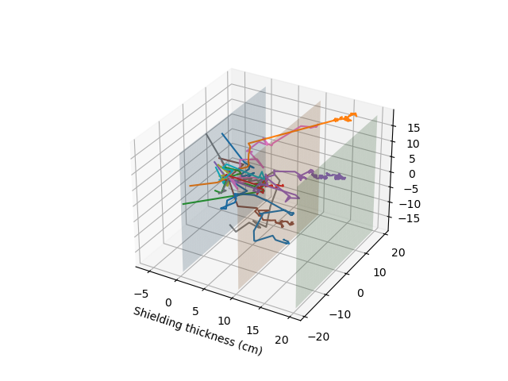

```
========================================================
Transmission through lead and water
--------------------------------------------------------
Thickness: 10 cm
Neutrons per run: 1000
Total neutrons: 10000
--------------------------------------------------------
Mean reflected: 852.2 +- 67.9
Mean absorbed: 146.4 +- 11.5
Mean transmitted: 1.4 +- 1.2
--------------------------------------------------------
Mean reflected %: 85.2 +- 6.8%
Mean absorbed %: 14.6 +- 1.1%
Mean transmitted %: 0.1 +- 0.1%

Runtime: 10.596 seconds
```

```python
data = lead_and_water.simulate_different_thicknesses([10], 10, 1000, True)
```